# DS5220 Project 1

## 3.3.1 Exercises

1. Fix the code in problem 3.3.1.1, and enter it below

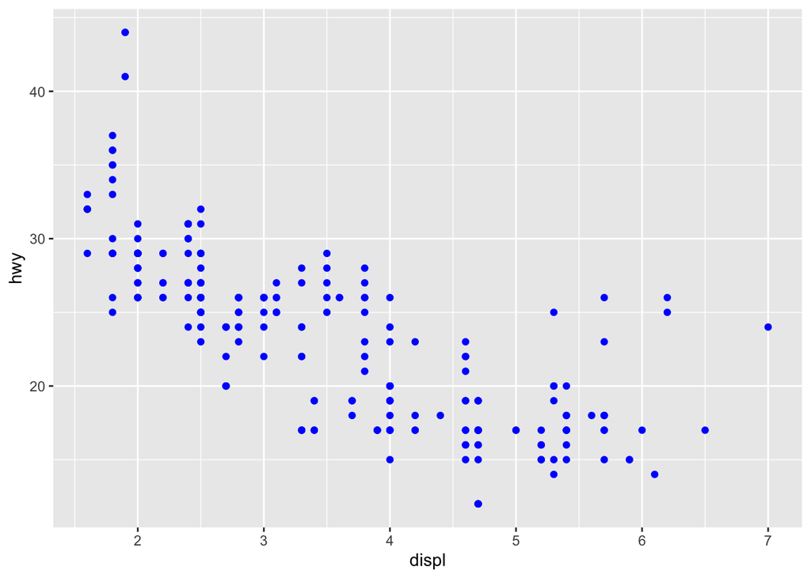

```r
ggplot(data = mpg) +
  geom_point(mapping = aes(x = displ, y = hwy), color = "blue")
```

2. Which variables in `mpg` are categorical? Which variables are continuous? (Hint: type `?mpg` in the Console Panel to read the documentation for the dataset in the Help Panel). How can you see this information when you run `mpg`?

```r
mpg
```

```
## # A tibble: 234 × 11
##    manufacturer model      displ  year   cyl trans drv     cty   hwy fl    class
##    <chr>        <chr>      <dbl> <int> <int> <chr> <chr> <int> <int> <chr> <chr>
##  1 audi         a4           1.8  1999     4 auto… f        18    29 p     comp…
##  2 audi         a4           1.8  1999     4 manu… f        21    29 p     comp…
##  3 audi         a4           2    2008     4 manu… f        20    31 p     comp…
##  4 audi         a4           2    2008     4 auto… f        21    30 p     comp…
##  5 audi         a4           2.8  1999     6 auto… f        16    26 p     comp…
##  6 audi         a4           2.8  1999     6 manu… f        18    26 p     comp…
##  7 audi         a4           3.1  2008     6 auto… f        18    27 p     comp…
##  8 audi         a4 quattro   1.8  1999     4 manu… 4        18    26 p     comp…
##  9 audi         a4 quattro   1.8  1999     4 auto… 4        16    25 p     comp…
## 10 audi         a4 quattro   2    2008     4 manu… 4        20    28 p     comp…
## # ℹ 224 more rows
```

Categorical variables: manufacturer, model, trans, drv, fl, class Continuous variables: displ, year, cyl, cty, hwy

3. Using your R code for 3.3.1.1, map a continuous variable to `color`, `size`, and `shape`. How does the aesthetic `shape` behave differently for mappings to `fl` and `displ`?

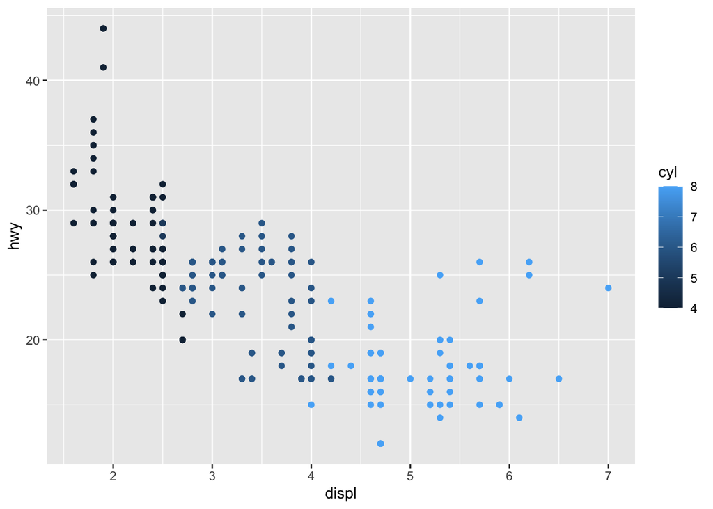

```r
ggplot(mpg, aes(x = displ, y = hwy, colour = cyl)) +
  geom_point()
```

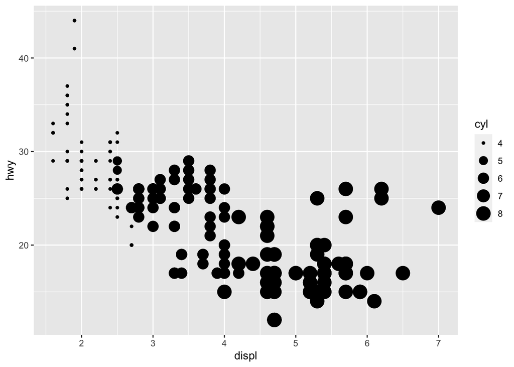

```r
ggplot(mpg, aes(x = displ, y = hwy, size = cyl)) +
  geom_point()
```

```r
#ggplot(mpg, aes(x = displ, y = hwy, shape = cty)) +
  #geom_point()
# Error: A continuous variable can not be mapped to shape
```

An error occurs when trying to map a continuous variable to a shape.

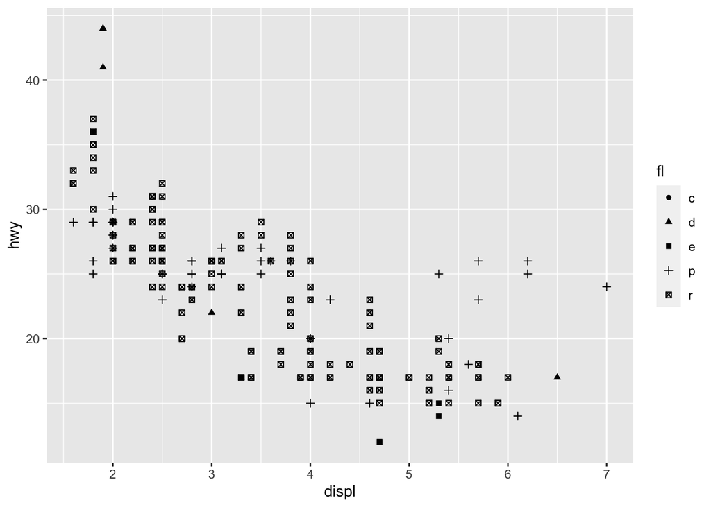

```r
ggplot(mpg, aes(x = displ, y = hwy, shape = fl)) +
  geom_point()
```

4. What happens if you map the same variable to multiple aesthetics? Use an example from your answers to problem 3.3.1.3.

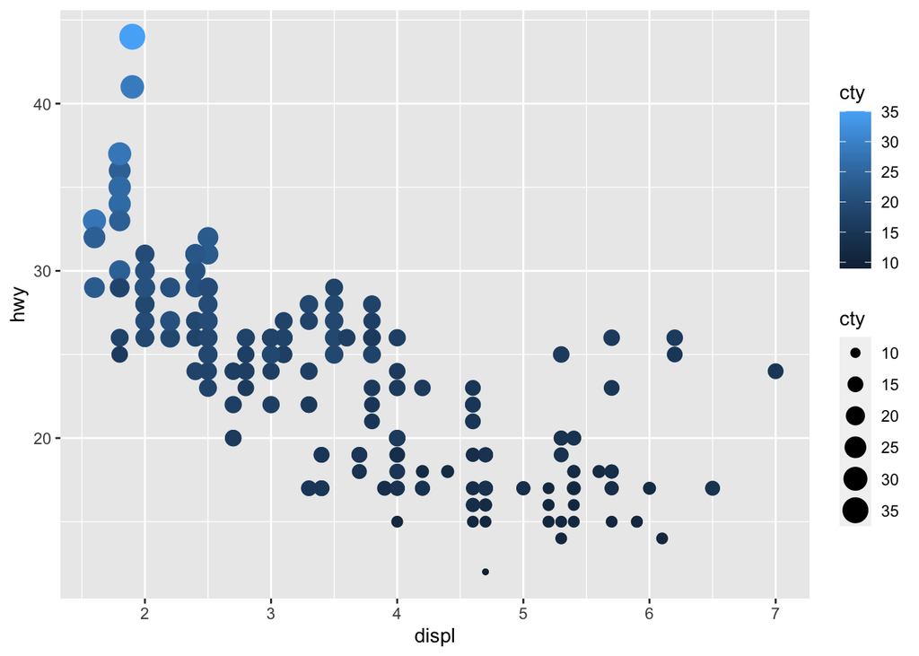

```r
ggplot(mpg, aes(x = displ, y = hwy, size = cty, color = cty)) +
  geom_point()
```

Mapping ‘cty’ to both color and size, shows us the same information in two different formats.

5. What does the `stroke` aesthetic do? What shapes does it work with? (Hint: use`?geom_point`) Try it with `shape=21` and `stroke=displ` in your code from 3.3.1.1.

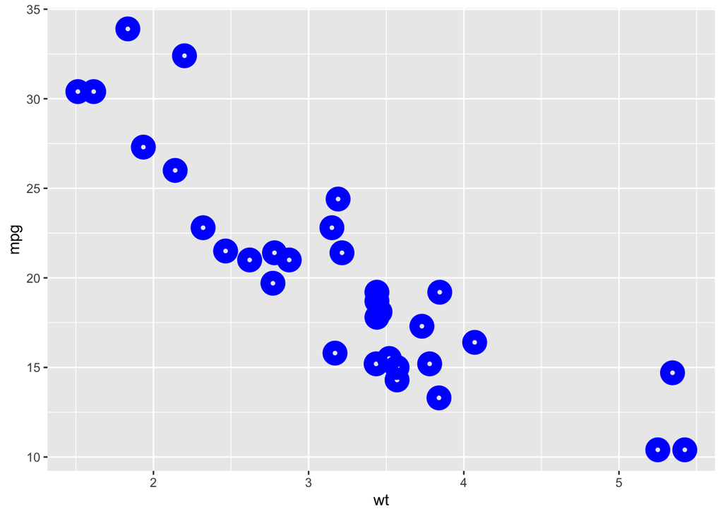

```r
ggplot(mtcars, aes(wt, mpg)) +
  geom_point(shape = 21, colour = "blue", stroke = 5)
```

The stroke aesthetic changes the size of the border for shapes.

6.What happens if you map an aesthetic to something other than a variable name, like `aes(colour = displ < 5)`? Try this by modifying your code in problem 3.3.1.1.

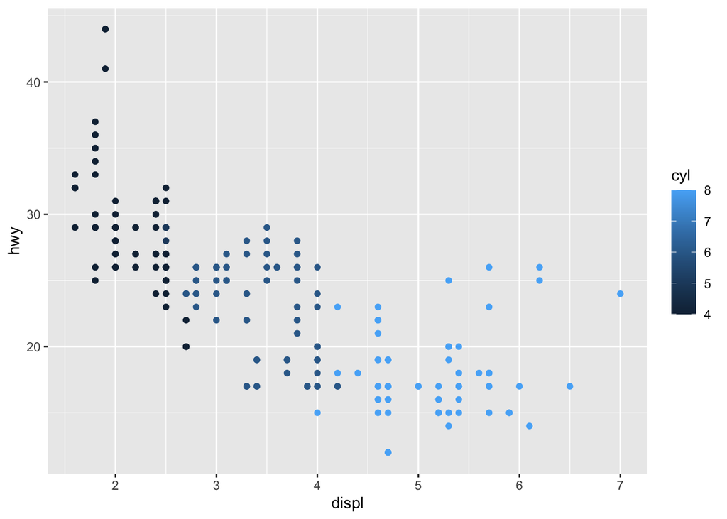

```r
ggplot(mpg, aes(x = displ, y = hwy, colour = cyl), color = displ < 5) +
  geom_point()
```